# Customer Churn Prediction for Telco Company

**Author:** Guillaume EGU

## Overview

This project aims to predict customer churn for a telecommunications company using supervised machine learning techniques. Customer churn prediction is crucial for businesses as it helps identify customers who are likely to discontinue their services, enabling proactive retention strategies and reducing revenue loss.

The dataset comes from IBM and contains information about telco customers, including demographics, services used, account information, and churn status. This analysis compares multiple machine learning algorithms on both original and resampled datasets to identify the most effective approach for churn prediction.

**Data Source:** https://community.ibm.com/community/user/blogs/steven-macko/2019/07/11/telco-customer-churn-1113

## Project Objectives

- Perform comprehensive exploratory data analysis (EDA) to understand churn patterns
- Compare multiple machine learning algorithms for churn prediction
- Evaluate the impact of data resampling techniques (SMOTEENN) on model performance
- Provide actionable business insights based on confusion matrix analysis

## Contents

- Import Libraries
- Functions
- EDA & Feature Engineering
- Models :
  - Logistic Regression
  - K-nearest neighbors
  - Naive Bayes
  - Support Vector Machine
  - Decision Tree
  - Random Forest
  - XGBoost
  - Gradient Boosting
  - AdaBoost
- Model Comparison & Analysis
- Business Insights
- Conclusion

### Import Libraries

Installation and importation of key libraries

```python
!pip install pandas
!pip install matplotlib
!pip install seaborn
!pip install scikit-learn
!pip install numpy
!pip install imblearn
!pip install xgboost
```

```
  Using cached imblearn-0.0-py2.py3-none-any.whl.metadata (355 bytes)
Using cached imblearn-0.0-py2.py3-none-any.whl (1.9 kB)
```

```python
# Handle the data
import pandas as pd
import numpy as np

# Visualization
import matplotlib
import matplotlib.pyplot as plt
import seaborn as sns

# Preprocessing and modeling
import sklearn
from sklearn.preprocessing import OneHotEncoder, MinMaxScaler, LabelEncoder, OneHotEncoder
from sklearn.model_selection import train_test_split, GridSearchCV, cross_val_score
from imblearn.combine import SMOTEENN

from sklearn.linear_model import LogisticRegression
from sklearn.neighbors import KNeighborsClassifier
from sklearn.svm import SVC
from sklearn.tree import DecisionTreeClassifier
from sklearn.ensemble import RandomForestClassifier, GradientBoostingClassifier, AdaBoostClassifier ,RandomForestRegressor
from xgboost import XGBClassifier
from sklearn.naive_bayes import GaussianNB
from sklearn.pipeline import Pipeline
from sklearn.metrics import accuracy_score, confusion_matrix, classification_report, mean_absolute_error, mean_squared_error, r2_score
```

### Data Load

Cell for loading the data in a single dataframe.

```python
df = pd.read_csv('datasets/IBM-Telco-Customer-Churn.csv')
df.head()
```

|  | customerID | gender | SeniorCitizen | Partner | Dependents | tenure | PhoneService | MultipleLines | InternetService | OnlineSecurity | ... | DeviceProtection | TechSupport | StreamingTV | StreamingMovies | Contract | PaperlessBilling | PaymentMethod | MonthlyCharges | TotalCharges | Churn |
| --- | --- | --- | --- | --- | --- | --- | --- | --- | --- | --- | --- | --- | --- | --- | --- | --- | --- | --- | --- | --- | --- |
| 0 | 7590-VHVEG | Female | 0 | Yes | No | 1 | No | No phone service | DSL | No | ... | No | No | No | No | Month-to-month | Yes | Electronic check | 29.85 | 29.85 | No |
| 1 | 5575-GNVDE | Male | 0 | No | No | 34 | Yes | No | DSL | Yes | ... | Yes | No | No | No | One year | No | Mailed check | 56.95 | 1889.5 | No |
| 2 | 3668-QPYBK | Male | 0 | No | No | 2 | Yes | No | DSL | Yes | ... | No | No | No | No | Month-to-month | Yes | Mailed check | 53.85 | 108.15 | Yes |
| 3 | 7795-CFOCW | Male | 0 | No | No | 45 | No | No phone service | DSL | Yes | ... | Yes | Yes | No | No | One year | No | Bank transfer (automatic) | 42.30 | 1840.75 | No |
| 4 | 9237-HQITU | Female | 0 | No | No | 2 | Yes | No | Fiber optic | No | ... | No | No | No | No | Month-to-month | Yes | Electronic check | 70.70 | 151.65 | Yes |

5 rows × 21 columns

### EDA and Feature engineering

In this step, I want to understand the data, prepare it for analyse and understand trends.

```python
df.info()
```

```
<class 'pandas.core.frame.DataFrame'>
RangeIndex: 7043 entries, 0 to 7042
Data columns (total 21 columns):
 #   Column            Non-Null Count  Dtype
---  ------            --------------  -----
 0   customerID        7043 non-null   object
 1   gender            7043 non-null   object
 2   SeniorCitizen     7043 non-null   int64
 3   Partner           7043 non-null   object
 4   Dependents        7043 non-null   object
 5   tenure            7043 non-null   int64
 6   PhoneService      7043 non-null   object
 7   MultipleLines     7043 non-null   object
 8   InternetService   7043 non-null   object
 9   OnlineSecurity    7043 non-null   object
 10  OnlineBackup      7043 non-null   object
 11  DeviceProtection  7043 non-null   object
 12  TechSupport       7043 non-null   object
 13  StreamingTV       7043 non-null   object
 14  StreamingMovies   7043 non-null   object
 15  Contract          7043 non-null   object
 16  PaperlessBilling  7043 non-null   object
 17  PaymentMethod     7043 non-null   object
 18  MonthlyCharges    7043 non-null   float64
 19  TotalCharges      7043 non-null   object
 20  Churn             7043 non-null   object
dtypes: float64(1), int64(2), object(18)
memory usage: 1.1+ MB
```

We understand there is 2 Int columns, 1 float column and 18 object columns. The dimensions are 21x7043 . Total charges should be int or float but not object => maybe there some errors in the dataset.

```python
df["TotalCharges"] = pd.to_numeric(df["TotalCharges"], errors='coerce')
df = df.dropna()
df.drop("customerID", axis=1, inplace=True)
```

Let's start to take a look at numerical columns

```python
df.describe()
```

|  | SeniorCitizen | tenure | MonthlyCharges | TotalCharges |
| --- | --- | --- | --- | --- |
| count | 7032.000000 | 7032.000000 | 7032.000000 | 7032.000000 |
| mean | 0.162400 | 32.421786 | 64.798208 | 2283.300441 |
| std | 0.368844 | 24.545260 | 30.085974 | 2266.771362 |
| min | 0.000000 | 1.000000 | 18.250000 | 18.800000 |
| 25% | 0.000000 | 9.000000 | 35.587500 | 401.450000 |
| 50% | 0.000000 | 29.000000 | 70.350000 | 1397.475000 |
| 75% | 0.000000 | 55.000000 | 89.862500 | 3794.737500 |
| max | 1.000000 | 72.000000 | 118.750000 | 8684.800000 |

Let's check unique values

```python
for col in df.columns :
    if df[col].dtype != 'int64' and df[col].dtype != 'float64' :
        print(f"{col} : {df[col].unique()}")
```

```
gender : ['Female' 'Male']
Partner : ['Yes' 'No']
Dependents : ['No' 'Yes']
PhoneService : ['No' 'Yes']
MultipleLines : ['No phone service' 'No' 'Yes']
InternetService : ['DSL' 'Fiber optic' 'No']
OnlineSecurity : ['No' 'Yes' 'No internet service']
OnlineBackup : ['Yes' 'No' 'No internet service']
DeviceProtection : ['No' 'Yes' 'No internet service']
TechSupport : ['No' 'Yes' 'No internet service']
StreamingTV : ['No' 'Yes' 'No internet service']
StreamingMovies : ['No' 'Yes' 'No internet service']
Contract : ['Month-to-month' 'One year' 'Two year']
PaperlessBilling : ['Yes' 'No']
PaymentMethod : ['Electronic check' 'Mailed check' 'Bank transfer (automatic)'
 'Credit card (automatic)']
Churn : ['No' 'Yes']
```

Let's verify null values

```python
print(df.isnull().sum())
```

```
gender              0
SeniorCitizen       0
Partner             0
Dependents          0
tenure              0
PhoneService        0
MultipleLines       0
InternetService     0
OnlineSecurity      0
OnlineBackup        0
DeviceProtection    0
TechSupport         0
StreamingTV         0
StreamingMovies     0
Contract            0
PaperlessBilling    0
PaymentMethod       0
MonthlyCharges      0
TotalCharges        0
Churn               0
dtype: int64
```

Now that we are sure the data are right. Let's visualize them.

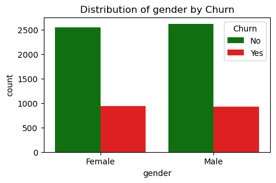

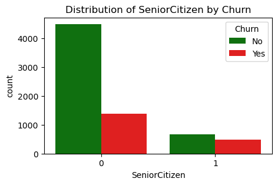

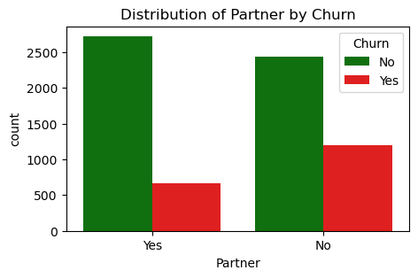

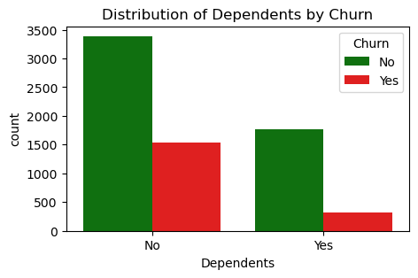

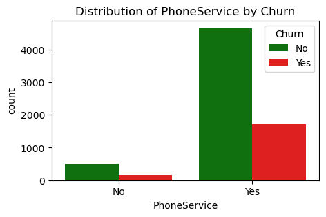

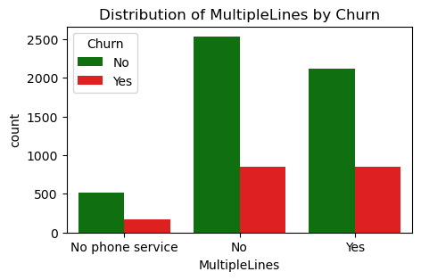

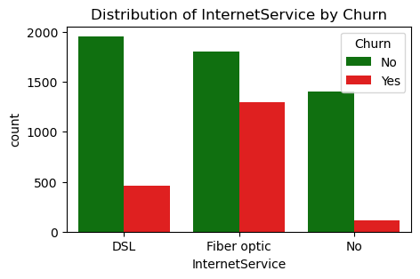

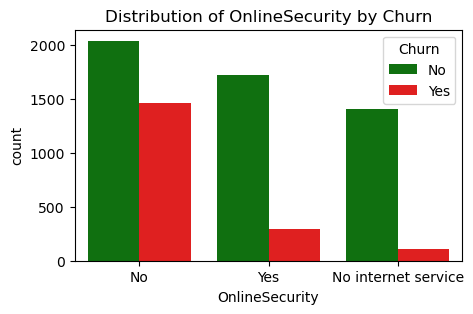

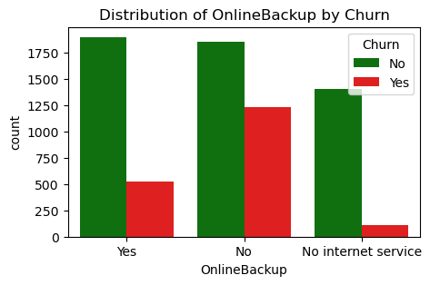

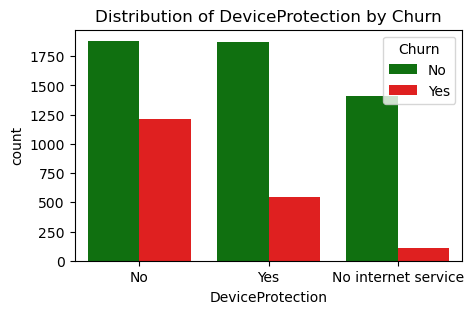

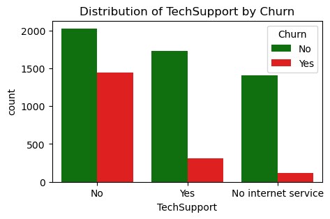

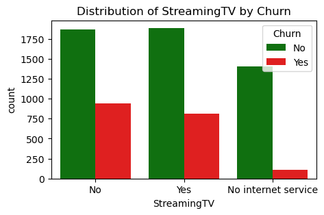

[4 more figures not shown]

```python
colors = {'Yes':'r', 'No':'g'}
palette = {0:'g', 1:'r'}

for i, predictor in enumerate(df.drop(columns=['Churn', 'TotalCharges', 'MonthlyCharges', 'tenure'])):
    plt.figure(i, figsize=(5,3))
    sns.countplot(data=df, x=predictor, hue='Churn', palette=colors)
    plt.title(f'Distribution of {predictor} by Churn')
    plt.show()
```

With numerical data

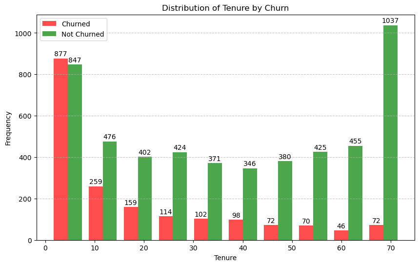

```python
churned = df[df['Churn'] == 'Yes']
not_churned = df[df['Churn'] == 'No']

plt.figure(figsize=(10,6))
plt.hist([churned['tenure'], not_churned['tenure']], bins=10, color=['r','g'], label=['Churned', 'Not Churned'], alpha=0.7)
plt.xlabel('Tenure')
plt.ylabel('Frequency')
plt.title('Distribution of Tenure by Churn')
plt.legend()
plt.grid(axis='y', alpha=0.75, linestyle='--')

for rect in plt.gca().patches:
    height = rect.get_height()
    if height > 0:
        plt.gca().text(rect.get_x() + rect.get_width() / 2, height + 5, f'{int(height)}', ha='center', va='bottom')
```

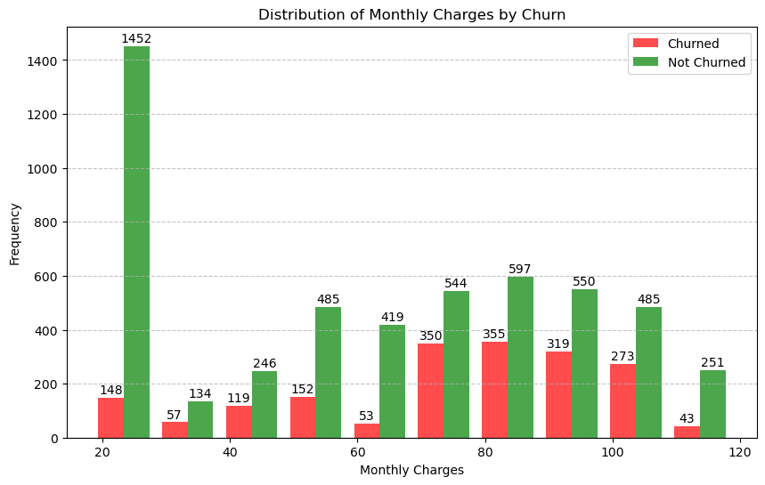

```python
churned= df[df['Churn'] == 'Yes']
not_churned = df[df['Churn'] == 'No']

plt.figure(figsize=(10,6))
plt.hist([churned['MonthlyCharges'], not_churned['MonthlyCharges']], bins=10, color=['r','g'], label=['Churned', 'Not Churned'], alpha=0.7)
plt.xlabel('Monthly Charges')
plt.ylabel('Frequency')
plt.title('Distribution of Monthly Charges by Churn')
plt.legend()
plt.grid(axis='y', alpha=0.75, linestyle='--')

for rect in plt.gca().patches:
    height = rect.get_height()
    if height > 0:
        plt.gca().text(rect.get_x() + rect.get_width() / 2, height + 5, f'{int(height)}', ha='center', va='bottom')
```

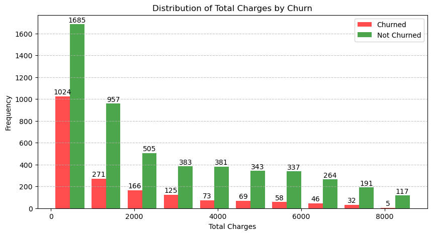

```python
churned = df[df['Churn'] == 'Yes']
not_churned = df[df['Churn'] == 'No']

plt.figure(figsize=(10,5))
plt.hist([churned['TotalCharges'], not_churned['TotalCharges']], bins=10, color=['r','g'], label=['Churned', 'Not Churned'], alpha=0.7)
plt.xlabel('Total Charges')
plt.ylabel('Frequency')
plt.title('Distribution of Total Charges by Churn')
plt.legend()
plt.grid(axis='y', alpha=0.75, linestyle='--')
for rect in plt.gca().patches:
    height = rect.get_height()
    if height > 0:
        plt.gca().text(rect.get_x() + rect.get_width() / 2, height + 5, f'{int(height)}', ha='center', va='bottom')
```

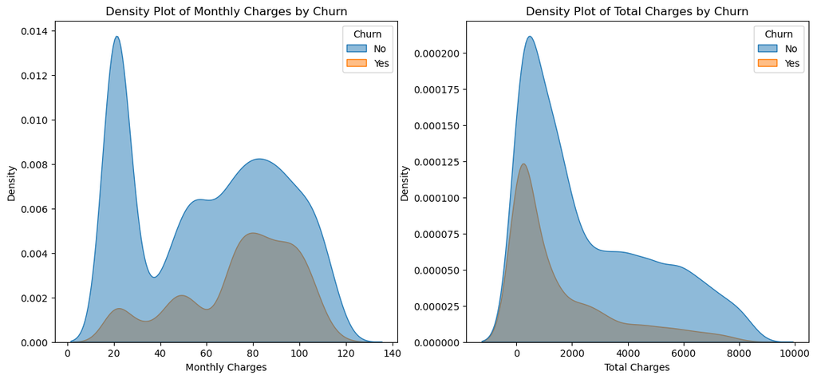

```python
fig, axes = plt.subplots(1, 2, figsize=(14,6))

sns.kdeplot(data=df, x='MonthlyCharges', hue='Churn', fill=True, alpha=0.5, ax=axes[0])
axes[0].set_title('Density Plot of Monthly Charges by Churn')
axes[0].set_xlabel('Monthly Charges')
axes[0].set_ylabel('Density')

sns.kdeplot(data=df, x='TotalCharges', hue='Churn', fill=True, alpha=0.5, ax=axes[1])
axes[1].set_title('Density Plot of Total Charges by Churn')
axes[1].set_xlabel('Total Charges')
axes[1].set_ylabel('Density')

plt.show()
```

We understand that some parameter like tenure or total charges will have more importance than others features.

Now, I will encode the data thanks to OneHotEncoder

```python
categorical_cols = df.select_dtypes(include=['category','object']).columns

encoder = OneHotEncoder(sparse_output=False)
encoded_data = encoder.fit_transform(df[categorical_cols])

encoded_df = pd.DataFrame(encoded_data, columns=encoder.get_feature_names_out(categorical_cols))

df.drop(columns=categorical_cols, inplace=True)

df.reset_index(drop=True, inplace=True)

df = pd.concat([df, encoded_df], axis=1)
```

```python
df.drop('Churn_No', axis=1, inplace=True)
df.rename(columns={'Churn_Yes':'Churn'}, inplace=True)
```

```python
df.head()
```

|  | SeniorCitizen | tenure | MonthlyCharges | TotalCharges | gender_Female | gender_Male | Partner_No | Partner_Yes | Dependents_No | Dependents_Yes | ... | Contract_Month-to-month | Contract_One year | Contract_Two year | PaperlessBilling_No | PaperlessBilling_Yes | PaymentMethod_Bank transfer (automatic) | PaymentMethod_Credit card (automatic) | PaymentMethod_Electronic check | PaymentMethod_Mailed check | Churn |
| --- | --- | --- | --- | --- | --- | --- | --- | --- | --- | --- | --- | --- | --- | --- | --- | --- | --- | --- | --- | --- | --- |
| 0 | 0 | 1 | 29.85 | 29.85 | 1.0 | 0.0 | 0.0 | 1.0 | 1.0 | 0.0 | ... | 1.0 | 0.0 | 0.0 | 0.0 | 1.0 | 0.0 | 0.0 | 1.0 | 0.0 | 0.0 |
| 1 | 0 | 34 | 56.95 | 1889.50 | 0.0 | 1.0 | 1.0 | 0.0 | 1.0 | 0.0 | ... | 0.0 | 1.0 | 0.0 | 1.0 | 0.0 | 0.0 | 0.0 | 0.0 | 1.0 | 0.0 |
| 2 | 0 | 2 | 53.85 | 108.15 | 0.0 | 1.0 | 1.0 | 0.0 | 1.0 | 0.0 | ... | 1.0 | 0.0 | 0.0 | 0.0 | 1.0 | 0.0 | 0.0 | 0.0 | 1.0 | 1.0 |
| 3 | 0 | 45 | 42.30 | 1840.75 | 0.0 | 1.0 | 1.0 | 0.0 | 1.0 | 0.0 | ... | 0.0 | 1.0 | 0.0 | 1.0 | 0.0 | 1.0 | 0.0 | 0.0 | 0.0 | 0.0 |
| 4 | 0 | 2 | 70.70 | 151.65 | 1.0 | 0.0 | 1.0 | 0.0 | 1.0 | 0.0 | ... | 1.0 | 0.0 | 0.0 | 0.0 | 1.0 | 0.0 | 0.0 | 1.0 | 0.0 | 1.0 |

5 rows × 46 columns

```python
X = df.drop('Churn', axis=1)
y = df['Churn']

X_train, X_test, y_train, y_test = train_test_split(X, y, test_size=0.2, random_state=42, stratify=y)

model_scores = []
```

```python
sm = SMOTEENN()
X_res, y_res = sm.fit_resample(X, y)

Xr_train, Xr_test, yr_train, yr_test = train_test_split(X_res, y_res, test_size=0.2)
model_scores_US = []
```

### Logistic Regression

```python
model = LogisticRegression(random_state=42)

pipeline = Pipeline([
    ('scaler', MinMaxScaler()),
    ('model', model)
])

grid_search = GridSearchCV(pipeline, param_grid={
    'model__C': [0.01, 0.1, 1, 10, 100],
    'model__penalty': ['l1', 'l2']
}, cv=2)


grid_search.fit(X_train, y_train)
pipeline = grid_search.best_estimator_

pipeline.fit(X_train, y_train)
y_pred = pipeline.predict(X_test)
accuracy = accuracy_score(y_test, y_pred)
model_scores.append(('Logistic Regression', accuracy, pipeline))


grid_search.fit(Xr_train, yr_train)
pipeline_r = grid_search.best_estimator_

pipeline_r.fit(Xr_train, yr_train)
y_pred_r = pipeline_r.predict(Xr_test)
accuracy_r = accuracy_score(yr_test, y_pred_r)
model_scores_US.append(('Logistic Regression', accuracy_r, pipeline_r))
```

[output not shown]

```python
model = KNeighborsClassifier()

pipeline = Pipeline([
    ('scaler', MinMaxScaler()),
    ('model', model)
])

grid_search = GridSearchCV(pipeline, param_grid={
    'model__n_neighbors': [3, 5, 7, 9],
    'model__weights': ['uniform', 'distance']
}, cv=2)


grid_search.fit(X_train, y_train)
pipeline = grid_search.best_estimator_

pipeline.fit(X_train, y_train)
y_pred = pipeline.predict(X_test)
accuracy = accuracy_score(y_test, y_pred)
model_scores.append(('K-nearest Neighbors', accuracy, pipeline))


grid_search.fit(Xr_train, yr_train)
pipeline_r = grid_search.best_estimator_

pipeline_r.fit(Xr_train, yr_train)
y_pred_r = pipeline_r.predict(Xr_test)
accuracy_r = accuracy_score(yr_test, y_pred_r)
model_scores_US.append(('K-nearest Neighbors', accuracy_r, pipeline_r))
```

### Naive Bayes

```python
model = GaussianNB()

pipeline = Pipeline([
    ('scaler', MinMaxScaler()),
    ('model', model)
])


pipeline.fit(X_train, y_train)
y_pred = pipeline.predict(X_test)
accuracy = accuracy_score(y_test, y_pred)
model_scores.append(('Gaussian Naive Bayes', accuracy, pipeline))


grid_search.fit(Xr_train, yr_train)
pipeline_r = grid_search.best_estimator_

pipeline_r.fit(Xr_train, yr_train)
y_pred_r = pipeline_r.predict(Xr_test)
accuracy_r = accuracy_score(yr_test, y_pred_r)
model_scores_US.append(('Gaussian Naive Bayes', accuracy_r, pipeline_r))
```

### Support Vector Machine

```python
model = SVC(random_state=42)

pipeline = Pipeline([
    ('scaler', MinMaxScaler()),
    ('model', model)
])

grid_search = GridSearchCV(pipeline, param_grid={
    'model__C': [0.01, 0.1, 1, 10, 100],
    'model__gamma': ['scale', 'auto']
}, cv=2)


grid_search.fit(X_train, y_train)
pipeline = grid_search.best_estimator_

pipeline.fit(X_train, y_train)
y_pred = pipeline.predict(X_test)
accuracy = accuracy_score(y_test, y_pred)
model_scores.append(('SVC', accuracy, pipeline))


grid_search.fit(Xr_train, yr_train)
pipeline_r = grid_search.best_estimator_

pipeline_r.fit(Xr_train, yr_train)
y_pred_r = pipeline_r.predict(Xr_test)
accuracy_r = accuracy_score(yr_test, y_pred_r)
model_scores_US.append(('SVC', accuracy_r, pipeline_r))
```

### Decision tree

```python
model = DecisionTreeClassifier(random_state=42)

pipeline = Pipeline([
    ('scaler', MinMaxScaler()),
    ('model', model)
])

grid_search = GridSearchCV(pipeline, param_grid={
    'model__max_depth': [3, 5, 7, 9, None],
    'model__min_samples_split': [2, 5, 10]
}, cv=2)


grid_search.fit(X_train, y_train)
pipeline = grid_search.best_estimator_

pipeline.fit(X_train, y_train)
y_pred = pipeline.predict(X_test)
accuracy = accuracy_score(y_test, y_pred)
model_scores.append(('Decision Tree', accuracy, pipeline))


grid_search.fit(Xr_train, yr_train)
pipeline_r = grid_search.best_estimator_

pipeline_r.fit(Xr_train, yr_train)
y_pred_r = pipeline_r.predict(Xr_test)
accuracy_r = accuracy_score(yr_test, y_pred_r)
model_scores_US.append(('Decision Tree', accuracy_r, pipeline_r))
```

### Random Forest

```python
model = RandomForestClassifier(random_state=42)

pipeline = Pipeline([
    ('scaler', MinMaxScaler()),
    ('model', model)
])

grid_search = GridSearchCV(pipeline, param_grid={
    'model__n_estimators': [50, 100, 200, 300, 400, 500],
    'model__max_depth': [None, 10, 20, 30, 40, 50]
}, cv=2)


grid_search.fit(X_train, y_train)
pipeline = grid_search.best_estimator_

pipeline.fit(X_train, y_train)
y_pred = pipeline.predict(X_test)
accuracy = accuracy_score(y_test, y_pred)
model_scores.append(('Random Forest', accuracy, pipeline))


grid_search.fit(Xr_train, yr_train)
pipeline_r = grid_search.best_estimator_

pipeline_r.fit(Xr_train, yr_train)
y_pred_r = pipeline_r.predict(Xr_test)
accuracy_r = accuracy_score(yr_test, y_pred_r)
model_scores_US.append(('Random Forest', accuracy_r, pipeline_r))
```

### XGBoost

```python
model = XGBClassifier(random_state=42)

pipeline = Pipeline([
    ('scaler', MinMaxScaler()),
    ('model', model)
])

grid_search = GridSearchCV(pipeline, param_grid={
    'model__n_estimators': [50, 100, 200, 300, 400, 500],
    'model__learning_rate': [0.01, 0.1, 0.2, 0.3],
    'model__max_depth': [3, 5, 7, 9]
}, cv=2)


grid_search.fit(X_train, y_train)
pipeline = grid_search.best_estimator_

pipeline.fit(X_train, y_train)
y_pred = pipeline.predict(X_test)
accuracy = accuracy_score(y_test, y_pred)
model_scores.append(('XGBoost', accuracy, pipeline))


grid_search.fit(Xr_train, yr_train)
pipeline_r = grid_search.best_estimator_

pipeline_r.fit(Xr_train, yr_train)
y_pred_r = pipeline_r.predict(Xr_test)
accuracy_r = accuracy_score(yr_test, y_pred_r)
model_scores_US.append(('XGBoost', accuracy_r, pipeline_r))
```

### Gradient Boosting

```python
model = GradientBoostingClassifier(random_state=42)

pipeline = Pipeline([
    ('scaler', MinMaxScaler()),
    ('model', model)
])

grid_search = GridSearchCV(pipeline, param_grid={
    'model__n_estimators': [50, 100, 200, 300, 400, 500],
    'model__learning_rate': [0.01, 0.1, 0.2, 0.3],
    'model__max_depth': [3, 5, 7, 9]
}, cv=2)


grid_search.fit(X_train, y_train)
pipeline = grid_search.best_estimator_

pipeline.fit(X_train, y_train)
y_pred = pipeline.predict(X_test)
accuracy = accuracy_score(y_test, y_pred)
model_scores.append(('Gradient Boosting', accuracy, pipeline))


grid_search.fit(Xr_train, yr_train)
pipeline_r = grid_search.best_estimator_

pipeline_r.fit(Xr_train, yr_train)
y_pred_r = pipeline_r.predict(Xr_test)
accuracy_r = accuracy_score(yr_test, y_pred_r)
model_scores_US.append(('Gradient Boosting', accuracy_r, pipeline_r))
```

### AdaBoost

```python
model = AdaBoostClassifier(random_state=42)

pipeline = Pipeline([
    ('scaler', MinMaxScaler()),
    ('model', model)
])

grid_search = GridSearchCV(pipeline, param_grid={
    'model__n_estimators': [50, 100, 200, 300, 400, 500],
    'model__learning_rate': [0.01, 0.1, 0.2, 0.3]
}, cv=2)


grid_search.fit(X_train, y_train)
pipeline = grid_search.best_estimator_

pipeline.fit(X_train, y_train)
y_pred = pipeline.predict(X_test)
accuracy = accuracy_score(y_test, y_pred)
model_scores.append(('AdaBoost', accuracy, pipeline))


grid_search.fit(Xr_train, yr_train)
pipeline_r = grid_search.best_estimator_

pipeline_r.fit(Xr_train, yr_train)
y_pred_r = pipeline_r.predict(Xr_test)
accuracy_r = accuracy_score(yr_test, y_pred_r)
model_scores_US.append(('AdaBoost', accuracy_r, pipeline_r))
```

[output not shown]

[output cut: 145 more lines]

[output not shown]

Summary

```python
scores_df = pd.DataFrame(model_scores, columns=['Model', 'Accuracy', 'Pipeline'])
scores_df_US = pd.DataFrame(model_scores_US, columns=['Model', 'Accuracy', 'Pipeline'])

best_model = None
best_accuracy = 0

for name, accuracy, pipeline in model_scores:
    print(f"{name} Accuracy: {accuracy:.4f}")

    if accuracy > best_accuracy:
        best_accuracy = accuracy
        best_model = name
        best_pipeline = pipeline

print(f"\nBest Model: {best_model} with Accuracy: {best_accuracy:.4f}")
print(f"Best Pipeline: {best_pipeline}")

best_model_US = None
best_accuracy_US = 0

for name, accuracy, pipeline in model_scores_US:
    print(f"{name} Accuracy: {accuracy:.4f}")

    if accuracy > best_accuracy_US:
        best_accuracy_US = accuracy
        best_model_US = name
        best_pipeline_US = pipeline

print(f"\nBest Model: {best_model_US} with Accuracy: {best_accuracy_US:.4f}")
print(f"Best Pipeline: {best_pipeline_US}")
```

```
Logistic Regression Accuracy: 0.8024
K-nearest Neighbors Accuracy: 0.7584
Gaussian Naive Bayes Accuracy: 0.6823
SVC Accuracy: 0.7896
Decision Tree Accuracy: 0.7783
Random Forest Accuracy: 0.7910
XGBoost Accuracy: 0.7960
Gradient Boosting Accuracy: 0.7932
AdaBoost Accuracy: 0.7932

Best Model: Logistic Regression with Accuracy: 0.8024
Best Pipeline: Pipeline(steps=[('scaler', MinMaxScaler()),
                ('model', LogisticRegression(C=1, random_state=42))])
Logistic Regression Accuracy: 0.9190
K-nearest Neighbors Accuracy: 0.8858
Gaussian Naive Bayes Accuracy: 0.8858
SVC Accuracy: 0.9378
Decision Tree Accuracy: 0.9344
Random Forest Accuracy: 0.9471
XGBoost Accuracy: 0.9616
Gradient Boosting Accuracy: 0.9650
AdaBoost Accuracy: 0.9506

Best Model: Gradient Boosting with Accuracy: 0.9650
Best Pipeline: Pipeline(steps=[('scaler', MinMaxScaler()),
                ('model',
                 GradientBoostingClassifier(learning_rate=0.2, max_depth=5,
                                            n_estimators=400,
                                            random_state=42))])
```

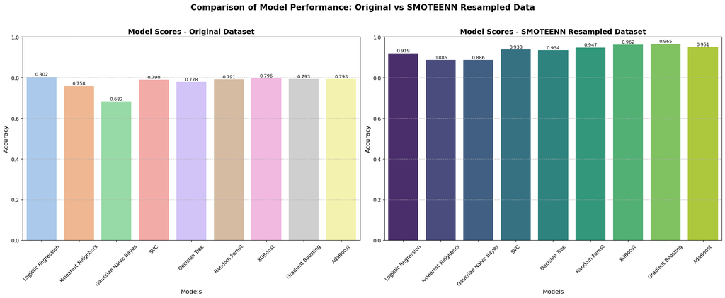

```
================================================================================
PERFORMANCE COMPARISON SUMMARY
================================================================================
Model                Original     SMOTEENN     Difference
--------------------------------------------------------------------------------
Logistic Regression  0.8024       0.9190       +0.1166
K-nearest Neighbors  0.7584       0.8858       +0.1274
Gaussian Naive Bayes 0.6823       0.8858       +0.2035
SVC                  0.7896       0.9378       +0.1481
Decision Tree        0.7783       0.9344       +0.1561
Random Forest        0.7910       0.9471       +0.1561
XGBoost              0.7960       0.9616       +0.1656
Gradient Boosting    0.7932       0.9650       +0.1719
AdaBoost             0.7932       0.9506       +0.1574
--------------------------------------------------------------------------------
```

```python
fig, axes = plt.subplots(1, 2, figsize=(20, 8))

colors1 = sns.color_palette('pastel', n_colors=len(scores_df))
colors2 = sns.color_palette('viridis', n_colors=len(scores_df_US))

ax1 = sns.barplot(x='Model', y='Accuracy', data=scores_df, palette=colors1, ax=axes[0])

for p in ax1.patches:
    ax1.annotate(f'{p.get_height():.3f}',
                (p.get_x() + p.get_width() / 2., p.get_height()),
                ha='center', va='center', fontsize=9, color='black', xytext=(0, 5),
                textcoords='offset points')

axes[0].set_title('Model Scores - Original Dataset', fontsize=14, fontweight='bold')
axes[0].set_xlabel('Models', fontsize=12)
axes[0].set_ylabel('Accuracy', fontsize=12)
axes[0].tick_params(axis='x', rotation=45)
axes[0].set_ylim(0, 1)
axes[0].grid(axis='y', linestyle='--', alpha=0.7)

ax2 = sns.barplot(x='Model', y='Accuracy', data=scores_df_US, palette=colors2, ax=axes[1])

for p in ax2.patches:
    ax2.annotate(f'{p.get_height():.3f}',
                (p.get_x() + p.get_width() / 2., p.get_height()),
                ha='center', va='center', fontsize=9, color='black', xytext=(0, 5),
                textcoords='offset points')

axes[1].set_title('Model Scores - SMOTEENN Resampled Dataset', fontsize=14, fontweight='bold')
axes[1].set_xlabel('Models', fontsize=12)
axes[1].set_ylabel('Accuracy', fontsize=12)
axes[1].tick_params(axis='x', rotation=45)
axes[1].set_ylim(0, 1)
axes[1].grid(axis='y', linestyle='--', alpha=0.7)

plt.suptitle('Comparison of Model Performance: Original vs SMOTEENN Resampled Data',
             fontsize=16, fontweight='bold', y=1.02)
plt.tight_layout()
plt.show()

print("\n" + "="*80)
print("PERFORMANCE COMPARISON SUMMARY")
print("="*80)
print(f"{'Model':<20} {'Original':<12} {'SMOTEENN':<12} {'Difference':<12}")
print("-"*80)

for i in range(len(scores_df)):
    model_name = scores_df.iloc[i]['Model']
    original_acc = scores_df.iloc[i]['Accuracy']
    smoteenn_acc = scores_df_US.iloc[i]['Accuracy']
    difference = smoteenn_acc - original_acc

    print(f"{model_name:<20} {original_acc:<12.4f} {smoteenn_acc:<12.4f} {difference:+.4f}")

print("-"*80)
```

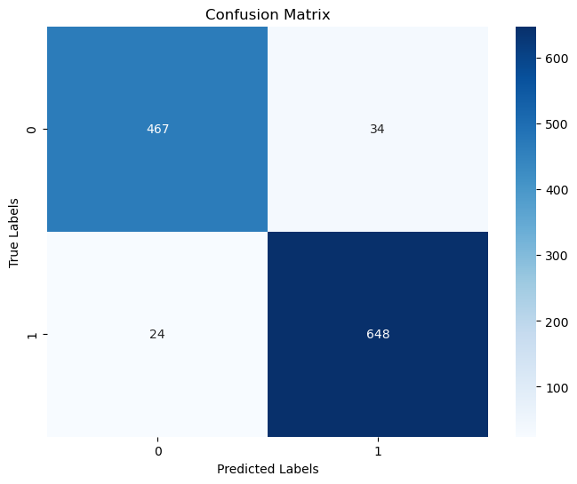

```python
conf_matrix = confusion_matrix(yr_test, y_pred_r)

plt.figure(figsize=(8, 6))
sns.heatmap(conf_matrix, annot=True, fmt="d", cmap="Blues", cbar=True)
plt.xlabel('Predicted Labels')
plt.ylabel('True Labels')
plt.title('Confusion Matrix')
plt.show()
```

Business Interpretation:

**False Negatives**: Customers who will churn but are not detected → Revenue loss  
**False Positives**: Loyal customers misclassified → Unnecessary retention costs

Business Impact:

**FN Cost** = Lost customers × Customer lifetime value  
**FP Cost** = Retention actions × Unit cost per action

Key Insights:

- **High FN**: Missing potential churners leads to direct revenue loss
- **High FP**: Wasting resources on customers who wouldn't churn anyway
- **Optimal balance**: Minimize total cost (FN + FP) for maximum ROI

## Conclusion

Key Findings

Business Value

This churn prediction model provides significant business value:

- **Revenue Protection**: Early identification of at-risk customers enables proactive retention, potentially saving thousands in lost revenue
- **Cost Optimization**: Targeted retention efforts reduce wasted marketing spend on loyal customers
- **Customer Insights**: Understanding churn drivers helps improve overall customer experience and service offerings
- **Competitive Advantage**: Data-driven retention strategies provide a significant advantage in the competitive telecom market

Future Work

- **Advanced Analytics**: Implement customer lifetime value prediction to prioritize retention efforts
- **Segmentation**: Develop churn models for specific customer segments (high-value, new customers, etc.)
- **Real-time Features**: Incorporate real-time behavioral data for more accurate predictions
- **A/B Testing**: Implement controlled experiments to measure the effectiveness of retention strategies

This project demonstrates the power of machine learning in solving real business problems and provides a solid foundation for implementing a comprehensive customer retention strategy.